# Point Loma Abalone Tag Analysis

Kevin L. Stierhoff

October 18, 2016

# Overview

Here I present a preliminary exploration of data from pinto abalone that were tagged and tracked at Pt. Loma between 2015-11-13 and 2016-05-17. The goal is to evaluate how to best filter the results to minimize positional errors and maximize information about movement distances, aggregation, etc.

For starters, filtered data consisted of a subset of abalone and sync tag data that had a horizontal position error (HPE) of $\leq$ 50, a speed between detections of $\leq$ 0.2 m/s, a computed distance between detections of $\leq$ 20 m. This reduced the number of detections from 23116 to 21788 for abalone tags (5.7% of detections removed), and 146603 to 133071 for sync tags (9.2% of detections removed).

# Summary statistics

## Abalone tag data

```
##        DETECTEDID    N         FirstRecord          LastRecord   MeanHPE
## 1  A69-1601-39418 3148 2015-11-13 22:00:19 2016-02-19 21:50:55  8.129574
## 2  A69-1601-39419   62 2015-12-17 17:27:47 2016-03-05 21:49:57  8.943548
## 3  A69-1601-39420  968 2015-11-13 23:04:01 2016-03-22 19:04:57  8.880992
## 4  A69-1601-39421    4 2015-11-16 23:13:48 2015-11-25 06:56:41  7.750000
## 5  A69-1601-39422  147 2015-11-15 10:12:21 2015-12-28 04:21:43  9.244898
## 6  A69-1601-39423 1519 2015-11-13 22:05:51 2016-01-07 12:32:12  8.339631
## 7  A69-1601-39424 1134 2015-11-14 16:20:41 2016-02-22 20:17:44  9.026014
## 8  A69-1601-39425  411 2015-11-14 06:56:25 2016-03-20 18:22:08  7.936740
## 9  A69-1601-39426 1846 2015-11-13 23:33:47 2016-05-09 20:59:59  9.810293
## 10 A69-1601-39427   12 2015-12-17 17:12:23 2016-01-02 20:24:45 10.016667
## 11 A69-1601-39428 2469 2015-11-13 22:16:26 2016-01-17 09:28:37  8.101985
## 12 A69-1601-39429  172 2015-11-14 00:54:05 2015-12-01 08:12:25  9.525581
## 13 A69-1601-39430   18 2015-12-17 17:40:29 2016-01-02 20:23:24  8.822222
## 14 A69-1601-39431  145 2015-11-13 22:24:51 2016-01-15 17:45:05  8.984138
```

[output cut: 47 more lines]

## Sync tag data

```
##       DETECTEDID     N         FirstRecord          LastRecord   MeanHPE
## 1 A69-1601-65045 19974 2015-11-13 23:20:50 2016-06-22 17:08:23 11.030129
## 2 A69-1601-65042 23022 2015-11-13 22:08:11 2016-06-22 17:00:26  6.968278
## 3 A69-9002-16318 15380 2016-02-04 18:28:31 2016-06-22 17:04:22  7.016534
## 4 A69-1601-65040 21008 2015-11-13 22:07:54 2016-06-22 17:09:53  9.503232
## 5 A69-1601-65041 19780 2015-11-13 22:22:07 2016-06-22 17:05:45  8.912710
## 6 A69-1601-65044 13093 2015-11-13 22:33:44 2016-06-22 17:06:56 14.938020
## 7 A69-1601-65039 20280 2015-11-13 22:47:15 2016-06-22 17:07:37 13.366529
## 8 A69-1601-65043 14066 2015-11-17 18:10:18 2016-06-22 17:06:07 46.734658
##   MeanDistance SdDistance
## 1     9.582994  11.984625
## 2     1.677150   2.166211
## 3     1.584696   1.900314
## 4     3.625005   5.936451
## 5     3.609733   5.916205
## 6    14.167221  15.334424
## 7     7.867057   9.081394
## 8    17.669691  17.315364
```

# Summary plots

## Abalone tag data

### Abalone tag detections over time

Histograms of abalone tag detections by weekly (7-d) bins, from the earliest to the latest detection of any tag.

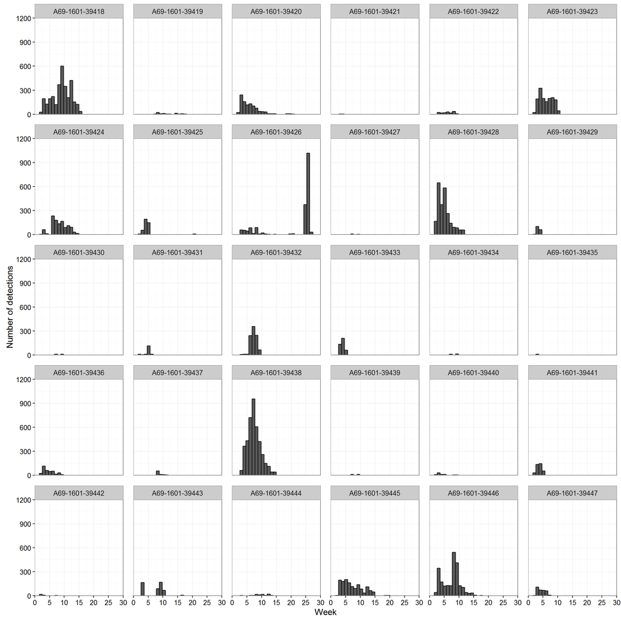

### Abalone tag movement distances between detections

Most abalone movements were less than 20 m between detections.

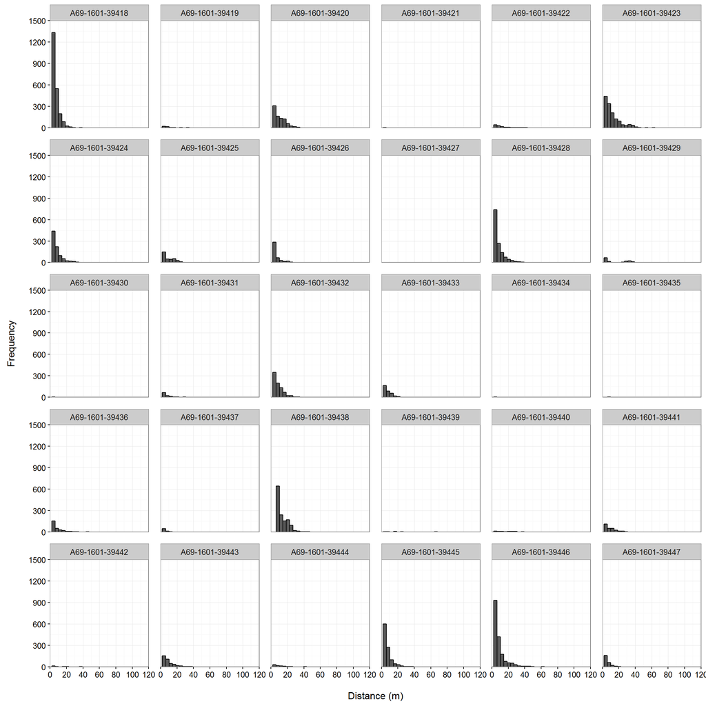

### Abalone tag movement speed between detections

The vast majority of abalone speeds appears to be less than 0.2 m/s, which could serve as a first pass cut-off for filtering.

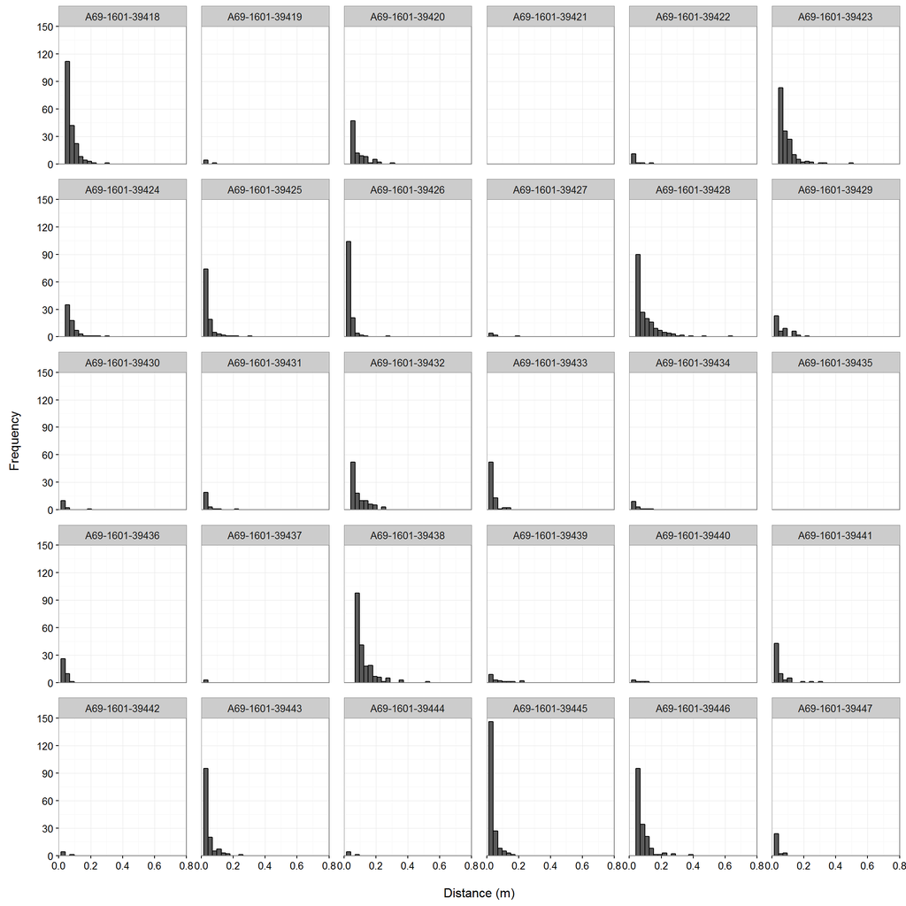

### Abalone tag movement distances between detections - FILTERED

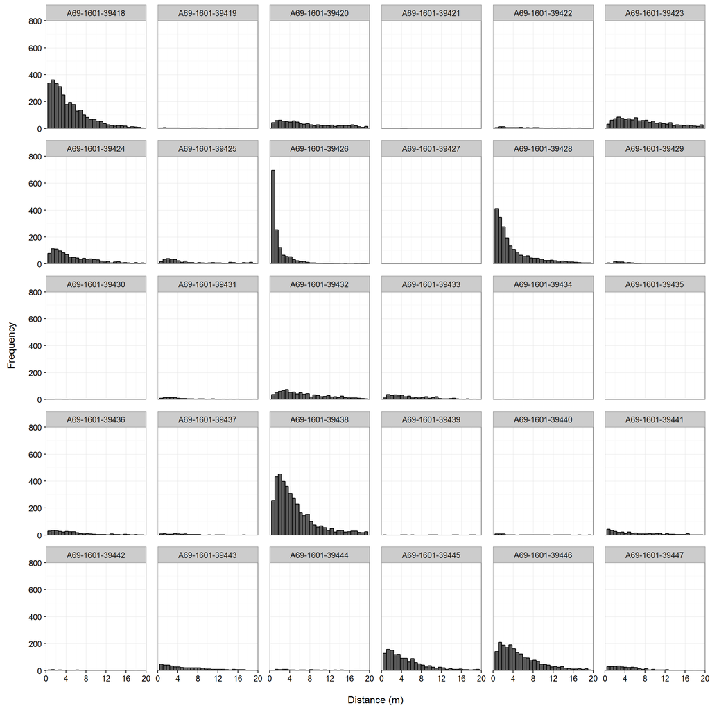

## Sync tag data

### Sync tag detections over time

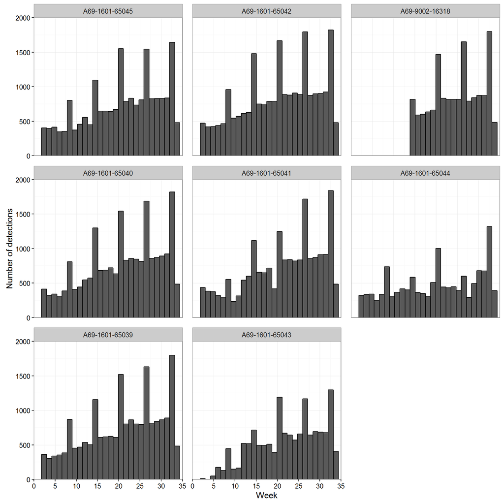

### Sync tag movement distances between detections

Interestingly, sync tag momements are often quite large.

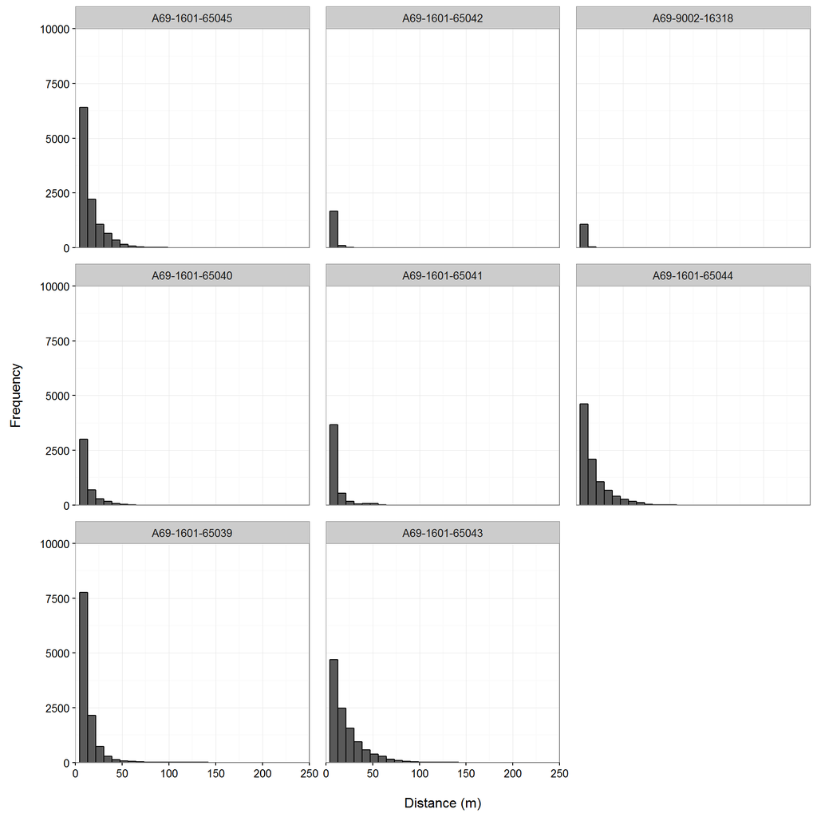

# Spatial plots

## Abalone tag data

### Plot of pinto abalone detection locations - UNFILTERED

Pinto abalone detection locations mapped relative to the hydrophone stations and symbolized by horizontal position error.

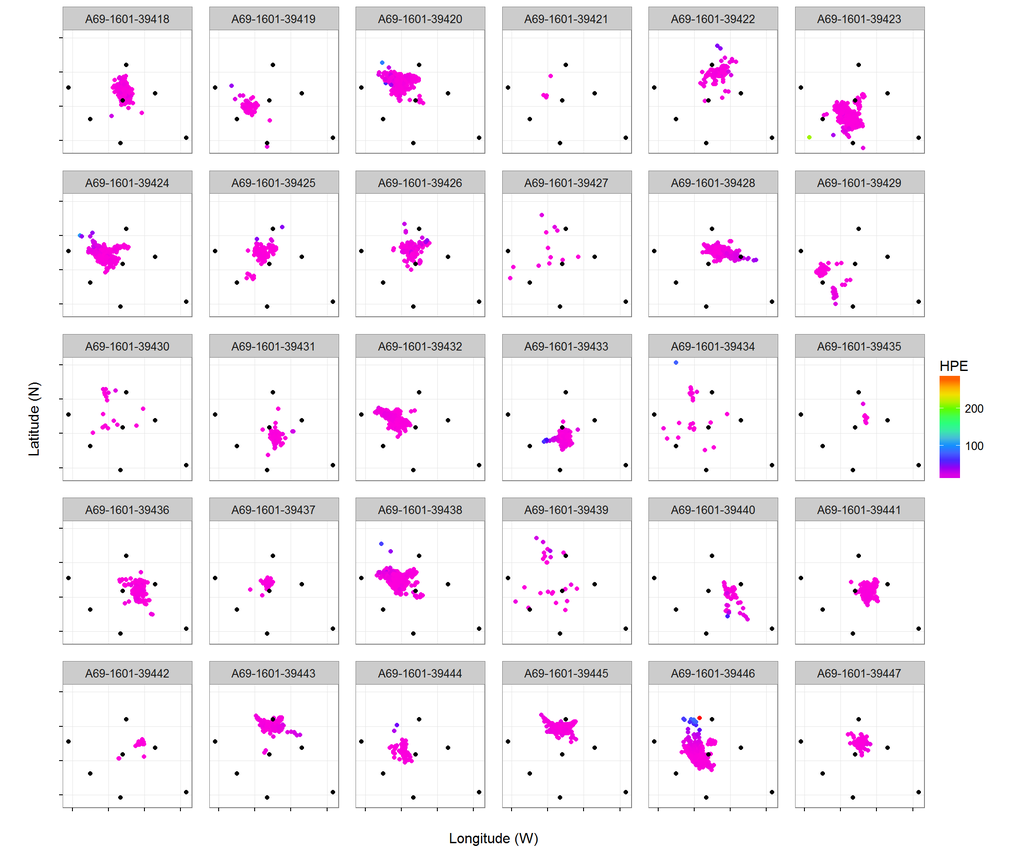

### Plot of pinto abalone detection locations - FILTERED Pinto abalone detection locations mapped relative to the hydrophone stations and symbolized by horizontal position error. Data have been filtered by HPE (HPE; threshold = 50) and distance (threshold = 20).

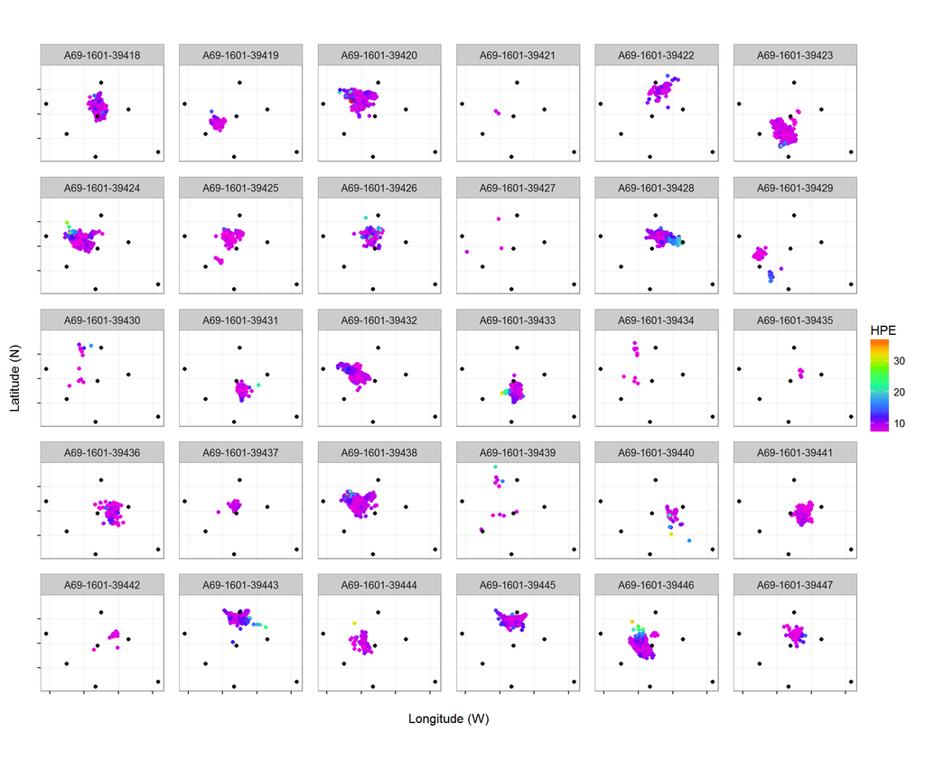

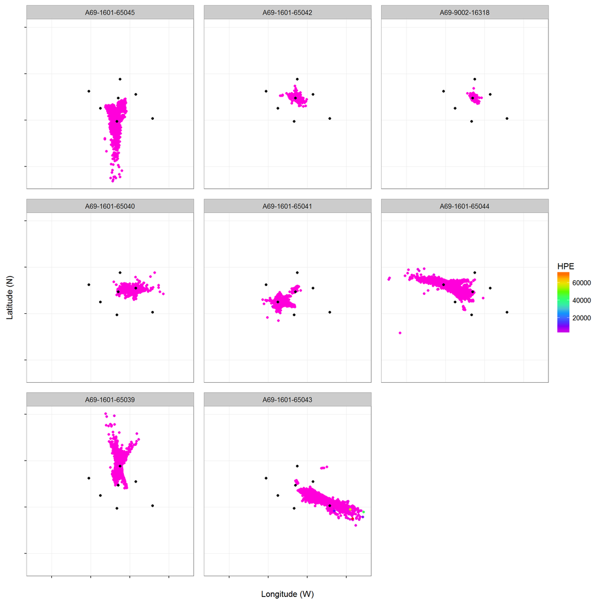

### Plot of sync tag detection locations - FILTERED

Sync tag detection locations mapped relative to the hydrophone stations and symbolized by horizontal position error. Data have been filtered by HPE (HPE; threshold = 50) and distance (threshold = 20).

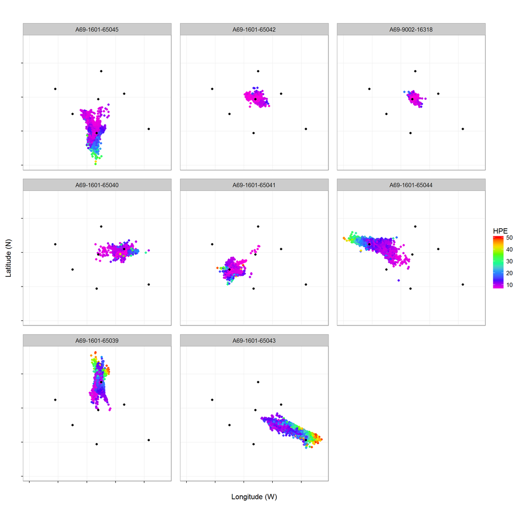

# Spatio-temporal plots

## Abalone tag data

### Plot of pinto abalone detection locations by individual and week

Each panel shows data from an individual abalone, symbolized by week.

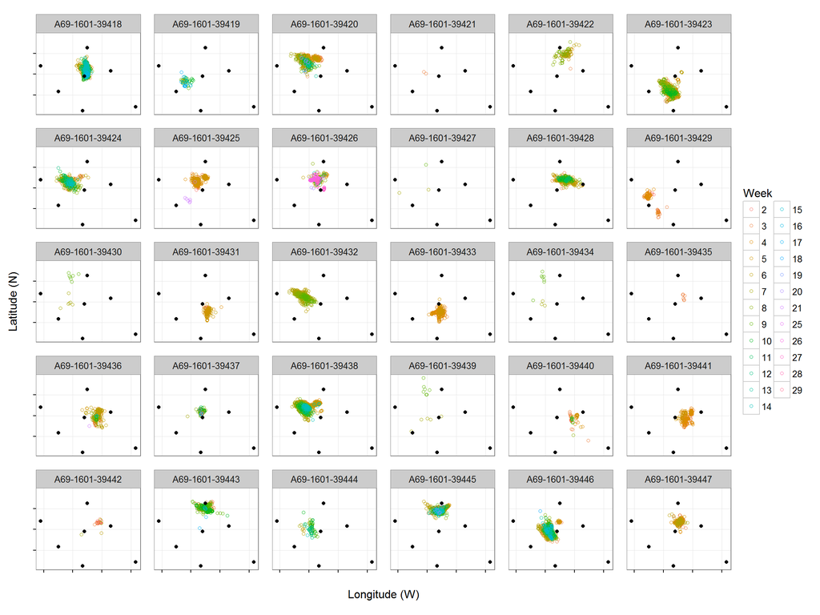

### Plot of pinto abalone detection locations by week

Each panel shows data from all abalone during each week of the study.

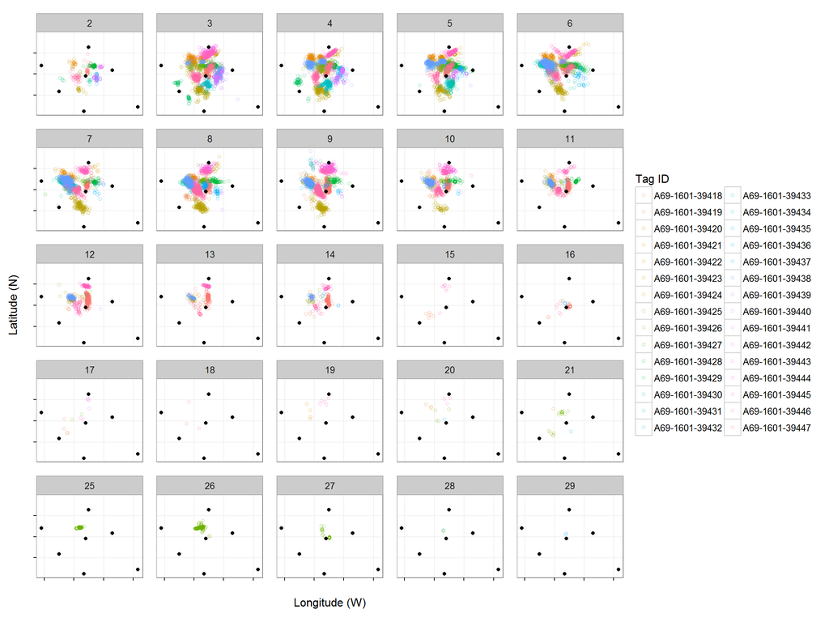

### Convex hulls around pinto abalone detections

Each panel shows the convex hull that encapsulates all abalone tag detections for each individual.

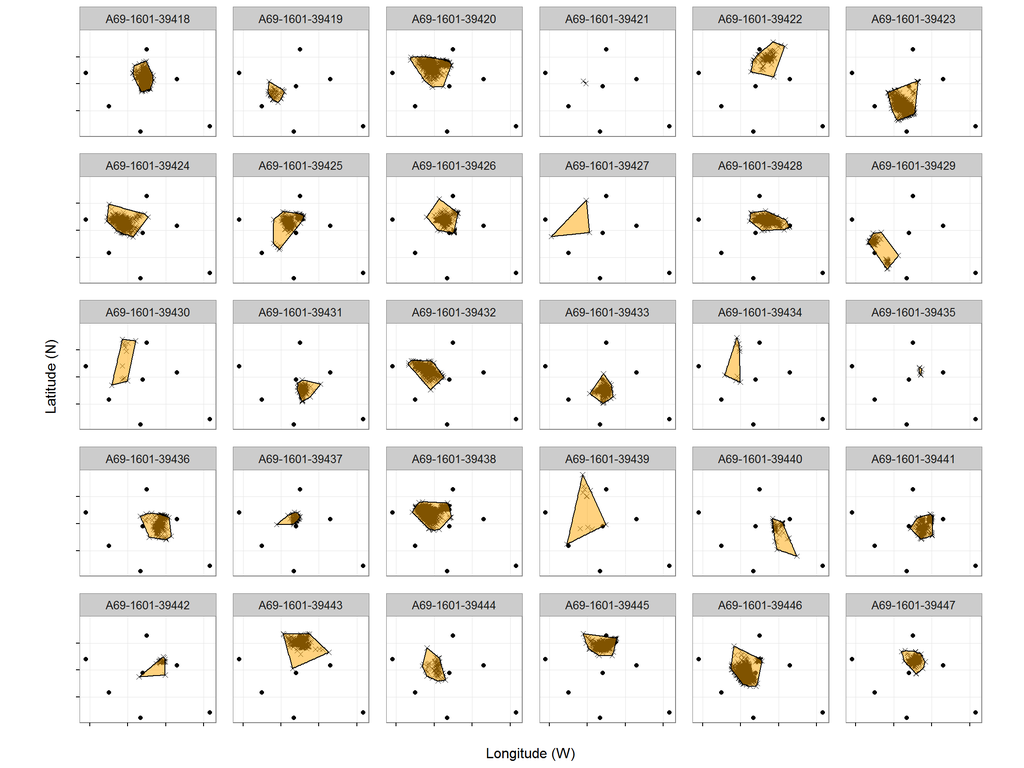

### Convex hulls around pinto abalone detections - ALL

Convex hulls that encapsulate each tagged abalone are shown in one plot. For clarity, only data from abalone tags with a minimum of 100 detections are shown. Apparently few, if any, abalone were observed in the SE portion of the study site.

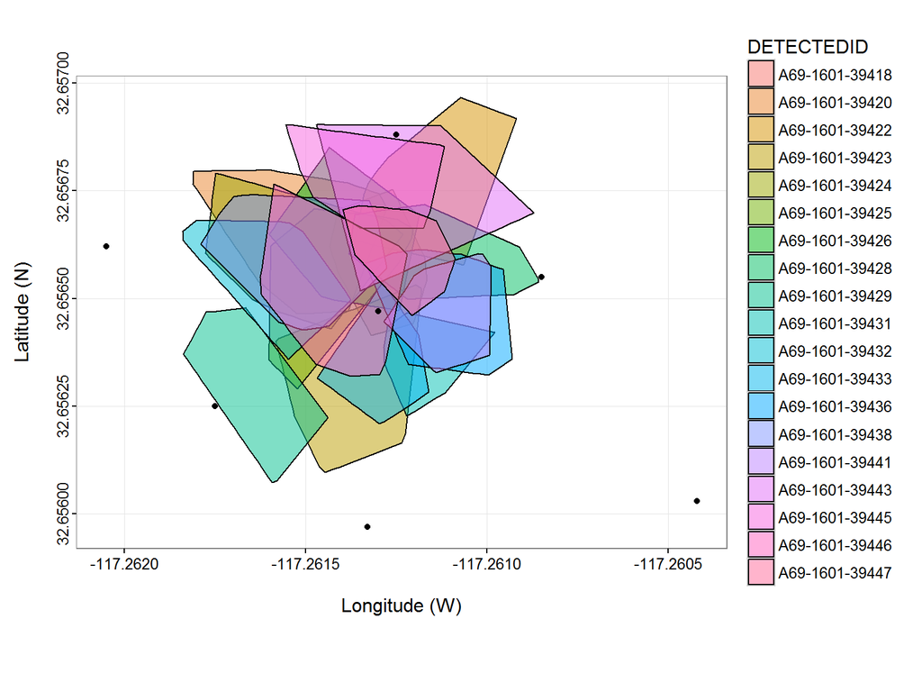